# Logistic Regression to Predict Rain Probability in SEATAC International Airport

Created By Julio SOLANO

Sep 07, 2018

# Setup

```r
 set.seed(101)
```

# Loading Libraries

```r
library(ROCR)           # ROC Curve
library(tidyverse)
library(dplyr)
library(Amelia)         # missmap function
library(ModelMetrics)
library(caTools)
library(caret)          # excercise 14, train, confusionMatrix fucntions
library(kableExtra)

#Organizing Packge information for table
packages <- c("ROCR", "tidyverse", "dplyr", "Amelia", "ModelMetrics", "caTools", "caret", "kableExtra")
display <- c("Package","Title", "Maintainer", "Version", "URL")
table <- matrix(NA, 1, NROW(display), dimnames = list(1, display))
for(i in 1:NROW(packages)){
list <- packageDescription(packages[i])
table <- rbind(table, matrix(unlist(list[c(display)]), 1, NROW(display), byrow = T))
}
table[,NROW(display)] <- stringr::str_extract(table[,NROW(display)], ".+,")

#Table of packages
kable(table[-1,], format = "html", align = "c") %>%
  kable_styling(bootstrap_options = c("striped", "hover", "condensed"))
```

|  | Package | Title | Maintainer | Version | URL |
| --- | --- | --- | --- | --- | --- |
|  | ROCR | Visualizing the Performance of Scoring Classifiers | Tobias Sing <tobias.sing@gmail.com>; | 1.0-7 | NA |
|  | tidyverse | Easily Install and Load the ‘Tidyverse’ | Hadley Wickham <hadley@rstudio.com>; | 1.2.1 | http://tidyverse.tidyverse.org, |
|  | dplyr | A Grammar of Data Manipulation | Hadley Wickham <hadley@rstudio.com>; | 0.7.5 | http://dplyr.tidyverse.org, |
|  | Amelia | A Program for Missing Data | Matthew Blackwell <mblackwell@gov.harvard.edu>; | 1.7.5 | NA |
|  | ModelMetrics | Rapid Calculation of Model Metrics | Tyler Hunt <thunt@snapfinance.com>; | 1.2.0 | NA |
|  | caTools | Tools: moving window statistics, GIF, Base64, ROC AUC, etc. | ORPHANED | 1.17.1.1 | NA |
|  | caret | Classification and Regression Training | Max Kuhn <mxkuhn@gmail.com>; | 6.0-80 | NA |
|  | kableExtra | Construct Complex Table with ‘kable’ and Pipe Syntax | Hao Zhu <haozhu233@gmail.com>; | 0.9.0 | http://haozhu233.github.io/kableExtra/, |

# Introduction and Problem Definition

La Regresión Logística Simple, desarrollada por David Cox en 1958, es un método de regresión que estima la probabilidad de una variable cualitativa en función de una variable cuantitativa. Permite estudiar en qué medida variaciones de una variable continua independiente influyen en una variable cualitativa dependiente.

```
  Una de las principales aplicaciones de la regresión logística es el análisis discriminante, en el que las observaciones se clasifican en un grupo u otro dependiendo del valor que tome la variable empleada como predictor. Por ejemplo, clasificar a un individuo desconocido como hombre o mujer en función del tamaño de la mandíbula. Si bien es posible emplear regresión logística para variables cualitativas con más de dos niveles, no es recomendable, en su lugar es preferible emplear Lineal Discriminant Analysis (LDA), Quadratic Discriminat Analysis (QDA) o K-NearestNeighboirs (K-NN).
```

Este proyecto proporcionar una guia paso a paso para construir un modelo de regresion logistica utilizando R. En este caso, usaremos una ‘regresion logistica binomial’, ya que la variable de decision solo puede tener dos valores. Sin embargo, tambien podemos predecir una variable de decision con mas de tres valores. Este tipo de regresion se llama “Regresion logistica multinomial”. En este proyecto, predecimos la probabilidad de lluvia en el aeropuerto SEATAC en Seattle, USA.

# Exercise 1: Data Source

```r
rain_data <- read.csv("RainSeattle2016.csv", header=T, na.strings = c(""))

str(rain_data)
```

```
## 'data.frame':    366 obs. of  20 variables:
##  $ Rain      : int  0 0 1 1 1 0 0 0 0 0 ...
##  $ NAME      : Factor w/ 1 level "SEATTLE TACOMA INTERNATIONAL AIRPORT, WA US": 1 1 1 1 1 1 1 1 1 1 ...
##  $ DATE      : Factor w/ 366 levels "01/01/2016","01/02/2016",..: 1 13 25 37 49 61 73 85 97 128 ...
##  $ Season    : Factor w/ 4 levels "Fall","Spring",..: 4 4 4 4 4 4 4 4 4 4 ...
##  $ AveWind   : num  4.92 5.59 9.17 7.61 5.37 6.49 2.91 1.57 2.91 8.05 ...
##  $ PRCP      : num  0 0 0.02 0.15 0.11 0 0 0 0 0 ...
##  $ SNOW      : num  0 0 0 0 0 0 0 0 0 0 ...
##  $ SNWD      : int  0 0 0 0 0 0 0 0 0 0 ...
##  $ TAVG      : int  36 33 37 36 38 44 41 42 39 43 ...
##  $ TMAX      : int  46 42 40 38 46 53 44 48 49 52 ...
##  $ TMIN      : int  28 25 31 35 36 37 34 36 30 38 ...
##  $ WDF5      : int  70 110 110 10 80 100 20 120 130 110 ...
##  $ WSF5      : num  13 29.1 36.9 17 18.1 16.1 8.9 14.1 12.1 21.9 ...
##  $ Fog       : int  NA 1 1 1 1 NA 1 1 1 NA ...
##  $ Heavy.Fog : int  NA NA NA NA NA NA 1 NA 1 NA ...
##  $ Thunder   : int  NA NA NA NA NA NA NA NA NA NA ...
##  $ Sleet     : logi  NA NA NA NA NA NA ...
##  $ Hail      : int  NA NA NA NA NA NA NA NA NA NA ...
##  $ Smoke     : int  NA NA NA NA NA NA NA NA NA NA ...
##  $ High.Winds: logi  NA NA NA NA NA NA ...
```

# Variables Description

**Rain**: is the column which we are trying to predict.

**NAME**: is the place where the weather data was recorded on respective DATE.

**PRCP and SNOW**: = Precipitation and Snow in inches

**SNWD**: = Snow depth.

**TAVG**: = Average Temperature in F.

**TMAX, TMIN**: = max and Min Temperature of the day in F.

**WDF5, WSF5**: - Direction of fastest 5-second wind in degree and Fastest 5-second wind speed respectively.

# Exercise 2: Missing Values

Vamos a chequear valores ausentes. Utilizaremos la funcion **missmap** que muestra valores ausentes en un mapa visual.

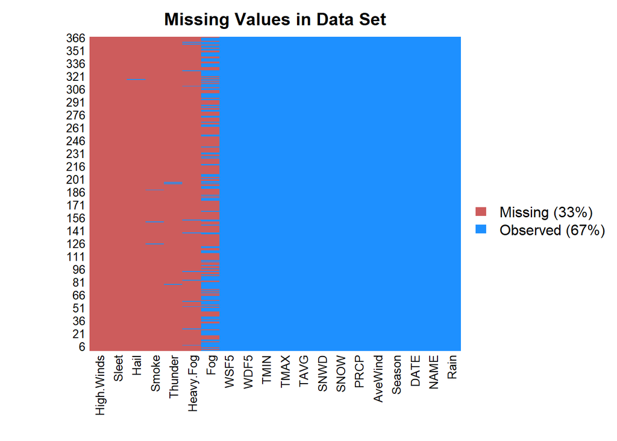

```r
missmap(rain_data, main="Missing Values in Data Set")
```

```r
rain_df <- subset(rain_data, select=c(1,3,4,5,7,8,9,10,11,12,13))
head(rain_df)
```

```
##   Rain       DATE Season AveWind SNOW SNWD TAVG TMAX TMIN WDF5 WSF5
## 1    0 01/01/2016 Winter    4.92    0    0   36   46   28   70 13.0
## 2    0 02/01/2016 Winter    5.59    0    0   33   42   25  110 29.1
## 3    1 03/01/2016 Winter    9.17    0    0   37   40   31  110 36.9
## 4    1 04/01/2016 Winter    7.61    0    0   36   38   35   10 17.0
## 5    1 05/01/2016 Winter    5.37    0    0   38   46   36   80 18.1
## 6    0 06/01/2016 Winter    6.49    0    0   44   53   37  100 16.1
```

Verifiquemos ahora si nuestro set de datos tiene valores “NA”. Una de las maneras mas comunes de tratar esto es excluir las filas que contienen valores “NA”s, o ajustar el valor faltante: media, mediana de cada columna, etc. Una alternativa más elegante consiste utilizar la función **mice()** del paquete mice, utilizando RandomForest.

```r
sapply(rain_df, function(x) sum(is.na(x)))
```

```
##    Rain    DATE  Season AveWind    SNOW    SNWD    TAVG    TMAX    TMIN
##       0       0       0       0       0       0       0       0       0
##    WDF5    WSF5
##       0       0
```

Vemos que no tenemos valores NA.

# Exercise 3: Categorization of Variables

```r
# a.
rain_df$Rain <- factor(rain_df$Rain)
rain_df$Season <- factor(rain_df$Season, ordered = FALSE)

# Contrasts
contrasts(rain_df$Rain)
```

```
##   1
## 0 0
## 1 1
```

```r
contrasts(rain_df$Season)
```

```
##        Spring Summer Winter
## Fall        0      0      0
## Spring      1      0      0
## Summer      0      1      0
## Winter      0      0      1
```

```r
# b.
rain_df$DATE <- as.Date(rain_df$DATE,'%m/%d/%Y')

str(rain_df)
```

```
## 'data.frame':    366 obs. of  11 variables:
##  $ Rain   : Factor w/ 2 levels "0","1": 1 1 2 2 2 1 1 1 1 1 ...
##  $ DATE   : Date, format: "2016-01-01" "2016-02-01" ...
##  $ Season : Factor w/ 4 levels "Fall","Spring",..: 4 4 4 4 4 4 4 4 4 4 ...
##  $ AveWind: num  4.92 5.59 9.17 7.61 5.37 6.49 2.91 1.57 2.91 8.05 ...
##  $ SNOW   : num  0 0 0 0 0 0 0 0 0 0 ...
##  $ SNWD   : int  0 0 0 0 0 0 0 0 0 0 ...
##  $ TAVG   : int  36 33 37 36 38 44 41 42 39 43 ...
##  $ TMAX   : int  46 42 40 38 46 53 44 48 49 52 ...
##  $ TMIN   : int  28 25 31 35 36 37 34 36 30 38 ...
##  $ WDF5   : int  70 110 110 10 80 100 20 120 130 110 ...
##  $ WSF5   : num  13 29.1 36.9 17 18.1 16.1 8.9 14.1 12.1 21.9 ...
```

# Exercise 4: Random Sampling (Train and Test)

Dividiremos el 70% de los datos para training y el 30% restante para test.

```r
split <- sample.split(rain_df$Rain, SplitRatio = 0.7)

train <- subset(rain_df, split==TRUE)
table(train$Rain)
```

```
##
##   0   1
## 136 120
```

```r
test <- subset(rain_df, split==FALSE)
table(test$Rain)
```

```
##
##  0  1
## 58 52
```

# Exercise 5: Fit the Model

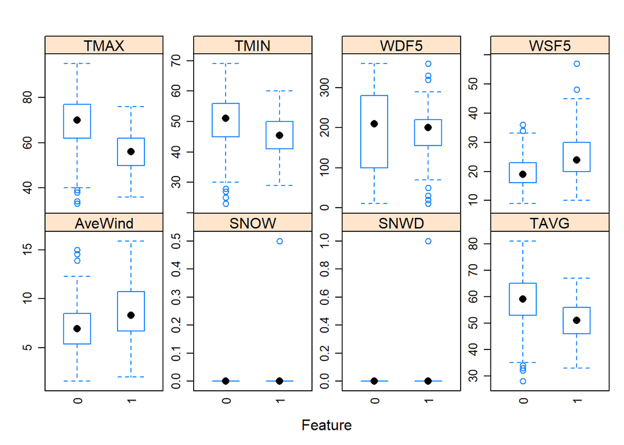

```r
# Exploratory Data Analysis
featurePlot(x = rain_df[, 4:11],
                  y = rain_df$Rain,
                  plot = "box",
                  ## Pass in options to bwplot()
                  scales = list(y = list(relation="free"),
                                x = list(rot = 90)),
                  layout = c(4,2 ),
                  auto.key = list(columns = 2))
```

```r
glm1 <- glm(Rain ~ Season+AveWind+SNOW+TAVG+TMAX+TMIN+WDF5+WSF5, family = binomial(link = "logit"), data = train)

# Model Statistics
summary(glm1)
```

```
##
## Call:
## glm(formula = Rain ~ Season + AveWind + SNOW + TAVG + TMAX +
##     TMIN + WDF5 + WSF5, family = binomial(link = "logit"), data = train)
##
## Deviance Residuals:
##     Min       1Q   Median       3Q      Max
## -2.8629  -0.5869  -0.1486   0.5627   2.5416
##
## Coefficients:
##                Estimate Std. Error z value Pr(>|z|)
## (Intercept)  -3.194e+00  1.490e+00  -2.143  0.03207 *
## SeasonSpring -3.132e-01  5.689e-01  -0.550  0.58198
## SeasonSummer -1.350e+00  6.481e-01  -2.082  0.03732 *
## SeasonWinter  8.034e-01  5.140e-01   1.563  0.11803
## AveWind      -7.551e-02  1.078e-01  -0.700  0.48371
## SNOW          2.827e+01  2.055e+03   0.014  0.98902
## TAVG         -1.032e-02  1.029e-01  -0.100  0.92005
## TMAX         -2.710e-01  6.194e-02  -4.376 1.21e-05 ***
## TMIN          3.930e-01  8.684e-02   4.525 6.03e-06 ***
## WDF5         -2.872e-03  2.059e-03  -1.395  0.16304
## WSF5          1.401e-01  4.834e-02   2.897  0.00376 **
## ---
## Signif. codes:  0 '***' 0.001 '**' 0.01 '*' 0.05 '.' 0.1 ' ' 1
##
## (Dispersion parameter for binomial family taken to be 1)
##
##     Null deviance: 353.89  on 255  degrees of freedom
## Residual deviance: 202.76  on 245  degrees of freedom
## AIC: 224.76
##
## Number of Fisher Scoring iterations: 14
```

# Exercise 6: Reduced Model

```r
RedModel <- step(glm1)
```

```
## Start:  AIC=224.76
## Rain ~ Season + AveWind + SNOW + TAVG + TMAX + TMIN + WDF5 +
##     WSF5
##
##           Df Deviance    AIC
## - TAVG     1   202.77 222.77
## - AveWind  1   203.25 223.25
## - SNOW     1   203.57 223.57
## - WDF5     1   204.72 224.72
## <none>         202.76 224.76
## - Season   3   212.27 228.27
## - WSF5     1   212.38 232.38
## - TMAX     1   225.70 245.70
## - TMIN     1   226.78 246.78
##
## Step:  AIC=222.77
## Rain ~ Season + AveWind + SNOW + TMAX + TMIN + WDF5 + WSF5
##
##           Df Deviance    AIC
## - AveWind  1   203.27 221.27
## - SNOW     1   203.59 221.59
## - WDF5     1   204.73 222.73
## <none>         202.77 222.77
## - Season   3   212.39 226.39
## - WSF5     1   212.38 230.38
## - TMAX     1   257.47 275.47
## - TMIN     1   262.80 280.80
##
## Step:  AIC=221.27
## Rain ~ Season + SNOW + TMAX + TMIN + WDF5 + WSF5
##
##          Df Deviance    AIC
## - SNOW    1   203.96 219.96
## - WDF5    1   205.08 221.08
## <none>        203.27 221.27
## - Season  3   214.20 226.20
## - WSF5    1   220.87 236.87
## - TMAX    1   258.36 274.36
## - TMIN    1   263.13 279.13
##
## Step:  AIC=219.96
## Rain ~ Season + TMAX + TMIN + WDF5 + WSF5
##
##          Df Deviance    AIC
## - WDF5    1   205.90 219.90
## <none>        203.96 219.96
## - Season  3   214.50 224.50
## - WSF5    1   222.56 236.56
## - TMAX    1   259.59 273.59
## - TMIN    1   263.46 277.46
##
## Step:  AIC=219.9
## Rain ~ Season + TMAX + TMIN + WSF5
##
##          Df Deviance    AIC
## <none>        205.90 219.90
## - Season  3   216.36 224.36
## - WSF5    1   223.27 235.27
## - TMAX    1   261.14 273.14
## - TMIN    1   264.00 276.00
```

# Exercise 7: Models Comparison

R usa la estadística de Chi-cuadrado para calcular el valor p, que se usa para tomar una decisión sobre la importancia estadística de los términos y el modelo. El valor p es una probabilidad que mide la evidencia contra la hipótesis nula (Coeficiente de la variable es igual a cero). Las probabilidades más bajas proporcionan evidencia más fuerte contra la hipótesis nula. Un estadístico chi-cuadrado suficientemente grande da como resultado un valor p pequeño, lo que indica que el término o modelo es estadísticamente significativo.

```r
glm2 <- glm(Rain ~ Season+AveWind+TMAX+TMIN+WSF5, family = binomial(link = "logit"), data = train)
summary(glm2)
```

```
##
## Call:
## glm(formula = Rain ~ Season + AveWind + TMAX + TMIN + WSF5, family = binomial(link = "logit"),
##     data = train)
##
## Deviance Residuals:
##     Min       1Q   Median       3Q      Max
## -2.8470  -0.6039  -0.1608   0.5545   2.3950
##
## Coefficients:
##              Estimate Std. Error z value Pr(>|z|)
## (Intercept)  -3.13647    1.44879  -2.165  0.03040 *
## SeasonSpring -0.38901    0.56104  -0.693  0.48808
## SeasonSummer -1.33006    0.64196  -2.072  0.03828 *
## SeasonWinter  0.76633    0.50839   1.507  0.13172
## AveWind      -0.05052    0.10519  -0.480  0.63102
## TMAX         -0.27442    0.04668  -5.879 4.13e-09 ***
## TMIN          0.37468    0.06027   6.217 5.07e-10 ***
## WSF5          0.12941    0.04761   2.718  0.00656 **
## ---
## Signif. codes:  0 '***' 0.001 '**' 0.01 '*' 0.05 '.' 0.1 ' ' 1
##
## (Dispersion parameter for binomial family taken to be 1)
##
##     Null deviance: 353.89  on 255  degrees of freedom
## Residual deviance: 205.67  on 248  degrees of freedom
## AIC: 221.67
##
## Number of Fisher Scoring iterations: 5
```

```r
glm3 <- glm(Rain ~ Season+TMAX+TMIN+WSF5, family = binomial(link = "logit"), data = train)
summary(glm3)
```

```
##
## Call:
## glm(formula = Rain ~ Season + TMAX + TMIN + WSF5, family = binomial(link = "logit"),
##     data = train)
##
## Deviance Residuals:
##     Min       1Q   Median       3Q      Max
## -2.8113  -0.6138  -0.1637   0.5526   2.3835
##
## Coefficients:
##              Estimate Std. Error z value Pr(>|z|)
## (Intercept)  -3.19220    1.44375  -2.211 0.027033 *
## SeasonSpring -0.43725    0.55311  -0.791 0.429220
## SeasonSummer -1.37229    0.63559  -2.159 0.030845 *
## SeasonWinter  0.79476    0.50494   1.574 0.115491
## TMAX         -0.27064    0.04588  -5.898 3.67e-09 ***
## TMIN          0.37092    0.05967   6.216 5.10e-10 ***
## WSF5          0.11216    0.03059   3.667 0.000246 ***
## ---
## Signif. codes:  0 '***' 0.001 '**' 0.01 '*' 0.05 '.' 0.1 ' ' 1
##
## (Dispersion parameter for binomial family taken to be 1)
##
##     Null deviance: 353.89  on 255  degrees of freedom
## Residual deviance: 205.90  on 249  degrees of freedom
## AIC: 219.9
##
## Number of Fisher Scoring iterations: 5
```

```r
glm4 <- glm(Rain ~ TMAX+TMIN+WSF5, family = binomial(link = "logit"), data = train)
summary(glm4)
```

```
##
## Call:
## glm(formula = Rain ~ TMAX + TMIN + WSF5, family = binomial(link = "logit"),
##     data = train)
##
## Deviance Residuals:
##     Min       1Q   Median       3Q      Max
## -2.4690  -0.7138  -0.1566   0.6294   2.5594
##
## Coefficients:
##             Estimate Std. Error z value Pr(>|z|)
## (Intercept) -0.71385    1.18455  -0.603    0.547
## TMAX        -0.28981    0.04305  -6.733 1.67e-11 ***
## TMIN         0.33432    0.05648   5.920 3.23e-09 ***
## WSF5         0.11843    0.02920   4.056 5.00e-05 ***
## ---
## Signif. codes:  0 '***' 0.001 '**' 0.01 '*' 0.05 '.' 0.1 ' ' 1
##
## (Dispersion parameter for binomial family taken to be 1)
##
##     Null deviance: 353.89  on 255  degrees of freedom
## Residual deviance: 216.36  on 252  degrees of freedom
## AIC: 224.36
##
## Number of Fisher Scoring iterations: 5
```

```r
anova(glm2, glm3, glm4, test='Chisq')
```

```
## Analysis of Deviance Table
##
## Model 1: Rain ~ Season + AveWind + TMAX + TMIN + WSF5
## Model 2: Rain ~ Season + TMAX + TMIN + WSF5
## Model 3: Rain ~ TMAX + TMIN + WSF5
##   Resid. Df Resid. Dev Df Deviance Pr(>Chi)
## 1       248     205.67
## 2       249     205.90 -1  -0.2312  0.63062
## 3       252     216.36 -3 -10.4576  0.01505 *
## ---
## Signif. codes:  0 '***' 0.001 '**' 0.01 '*' 0.05 '.' 0.1 ' ' 1
```

# Exercise 8: The Best Model

```r
glm5 <- glm(Rain ~ Season+TMAX+TMIN+WSF5, family = binomial(link = "logit"), data = train)
summary(glm5)
```

```
##
## Call:
## glm(formula = Rain ~ Season + TMAX + TMIN + WSF5, family = binomial(link = "logit"),
##     data = train)
##
## Deviance Residuals:
##     Min       1Q   Median       3Q      Max
## -2.8113  -0.6138  -0.1637   0.5526   2.3835
##
## Coefficients:
##              Estimate Std. Error z value Pr(>|z|)
## (Intercept)  -3.19220    1.44375  -2.211 0.027033 *
## SeasonSpring -0.43725    0.55311  -0.791 0.429220
## SeasonSummer -1.37229    0.63559  -2.159 0.030845 *
## SeasonWinter  0.79476    0.50494   1.574 0.115491
## TMAX         -0.27064    0.04588  -5.898 3.67e-09 ***
## TMIN          0.37092    0.05967   6.216 5.10e-10 ***
## WSF5          0.11216    0.03059   3.667 0.000246 ***
## ---
## Signif. codes:  0 '***' 0.001 '**' 0.01 '*' 0.05 '.' 0.1 ' ' 1
##
## (Dispersion parameter for binomial family taken to be 1)
##
##     Null deviance: 353.89  on 255  degrees of freedom
## Residual deviance: 205.90  on 249  degrees of freedom
## AIC: 219.9
##
## Number of Fisher Scoring iterations: 5
```

```r
anova(glm5, test='Chisq')
```

```
## Analysis of Deviance Table
##
## Model: binomial, link: logit
##
## Response: Rain
##
## Terms added sequentially (first to last)
##
##
##        Df Deviance Resid. Df Resid. Dev  Pr(>Chi)
## NULL                     255     353.89
## Season  3   52.776       252     301.12 2.047e-11 ***
## TMAX    1    5.940       251     295.18    0.0148 *
## TMIN    1   71.910       250     223.27 < 2.2e-16 ***
## WSF5    1   17.364       249     205.90 3.086e-05 ***
## ---
## Signif. codes:  0 '***' 0.001 '**' 0.01 '*' 0.05 '.' 0.1 ' ' 1
```

Se considera que el modelo es útil si es capaz de mostrar una mejora explicando las observaciones respecto al modelo nulo (sin predictores). En este caso, el modelo obtenido sí es significativo.

# Exercise 9: IC at 95%

```r
exp(cbind(OR = coef(glm5), confint(glm5)))
```

```
##                      OR       2.5 %    97.5 %
## (Intercept)  0.04108133 0.002229924 0.6593039
## SeasonSpring 0.64581110 0.216570961 1.9160792
## SeasonSummer 0.25352693 0.071209586 0.8719759
## SeasonWinter 2.21391904 0.837253508 6.1330798
## TMAX         0.76289278 0.692041414 0.8292936
## TMIN         1.44906102 1.298849610 1.6434781
## WSF5         1.11868634 1.057464226 1.1924196
```

# Exercise 10: Predictions (las predicciones estan en probabilidad en lugar de log_ODDs)

```r
# With Train Set
predicted.train <- ifelse(predict(glm5, newdata = train, type = "response") > 0.5, 1, 0)

# Print the predictions:
data.frame(Date = train$DATE, Rain_Actual = train$Rain, Predicted_Rain = predicted.train)
```

```
##           Date Rain_Actual Predicted_Rain
## 1   2016-01-01           0              0
## 2   2016-02-01           0              0
## 4   2016-04-01           1              1
## 6   2016-06-01           0              0
## 7   2016-07-01           0              0
## 8   2016-08-01           0              0
## 9   2016-09-01           0              0
## 10  2016-10-01           0              1
## 12  2016-12-01           1              1
## 13  2016-01-13           1              1
## 14  2016-01-14           0              0
## 15  2016-01-15           1              0
## 16  2016-01-16           1              1
## 17  2016-01-17           1              1
```

[output cut: 242 more lines]

```r
# With Test Set
predicted <- ifelse(predict(glm5, newdata = test, type = "response") > 0.5, 1, 0)

# Print the predictions:
data.frame(Date = test$DATE, Rain_Actual = test$Rain, Predicted_Rain = predicted)
```

```
##           Date Rain_Actual Predicted_Rain
## 3   2016-03-01           1              1
## 5   2016-05-01           1              1
## 11  2016-11-01           1              1
## 19  2016-01-19           1              1
## 21  2016-01-21           1              1
## 23  2016-01-23           1              1
## 28  2016-01-28           1              1
## 31  2016-01-31           0              1
## 36  2016-05-02           1              1
## 39  2016-08-02           0              0
## 49  2016-02-18           1              1
## 51  2016-02-20           0              1
## 52  2016-02-21           1              0
## 53  2016-02-22           1              0
```

[output cut: 96 more lines]

# Exercise 11: Confusion Matrix

```r
# Training
table(train$Rain, predicted.train)
```

```
##    predicted.train
##       0   1
##   0 111  25
##   1  25  95
```

```r
# Testing
table(test$Rain, predicted)
```

```
##    predicted
##      0  1
##   0 43 15
##   1  9 43
```

El modelo es capaz de clasificar correctamente (111+95)/(111+95+25+25)=0.80 (80%) de las observaciones cuando se emplea el trainig data set. Por otro lado, el modelo es capaz de clasificar correctamente (43+43)/(43+43+9+15)=0.78 (78%) de las observaciones cuando se emplea el testing data set.

# Exercise 12: Accuracy

```r
accuracy.train <- 1-mean(predicted.train != train$Rain)
accuracy.train
```

```
## [1] 0.8046875
```

```r
accuracy.test <- 1-mean(predicted != test$Rain)
accuracy.test
```

```
## [1] 0.7818182
```

La eaxactitud de nuestro modelo es 78.2%. Este es un valor razonable para nuestro modelo. La precisión puede aumentarse al verificar la curva ROCR y hacer los ajustes necesarios en el umbral de probabilidad.

# Exercise 13: ROC Curve

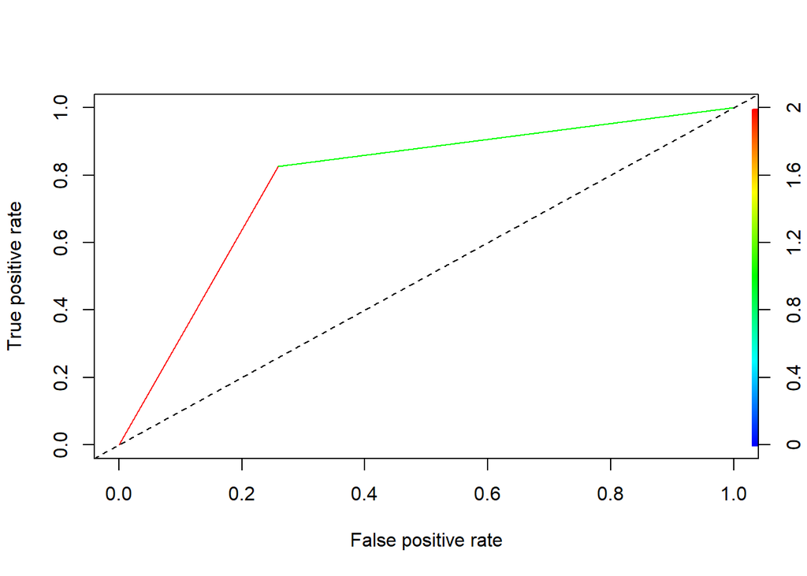

```r
ROCRPred <- prediction(predicted, test$Rain)
ROCRperf <- performance(ROCRPred, measure='tpr', x.measure='fpr')

# Plot the ROC Curve
plot(ROCRperf, colorize=TRUE)
abline(0, 1, lty = 2)
```

```r
# Calculate the Area under curve(AUC)
auc <- auc(test$Rain, predicted)
auc
```

```
## [1] 0.7841512
```

AUC is 78.4%, lo cual indica que nuestro modelo es bueno.

## Exercise 14: Conclusión (Modelo Logit)

$$logit(Rain) = −3.1920 -0.43725*SeasonSpring -1.37229*SeasonSummer +0.79476*SeasonWinter -0.27064*TMAX + 0.37092*TMIN + 0.11216*WSF5$$

$$P(Rain) = \frac{e^logit(Rain)}{1 + e^logit(Rain)}$$

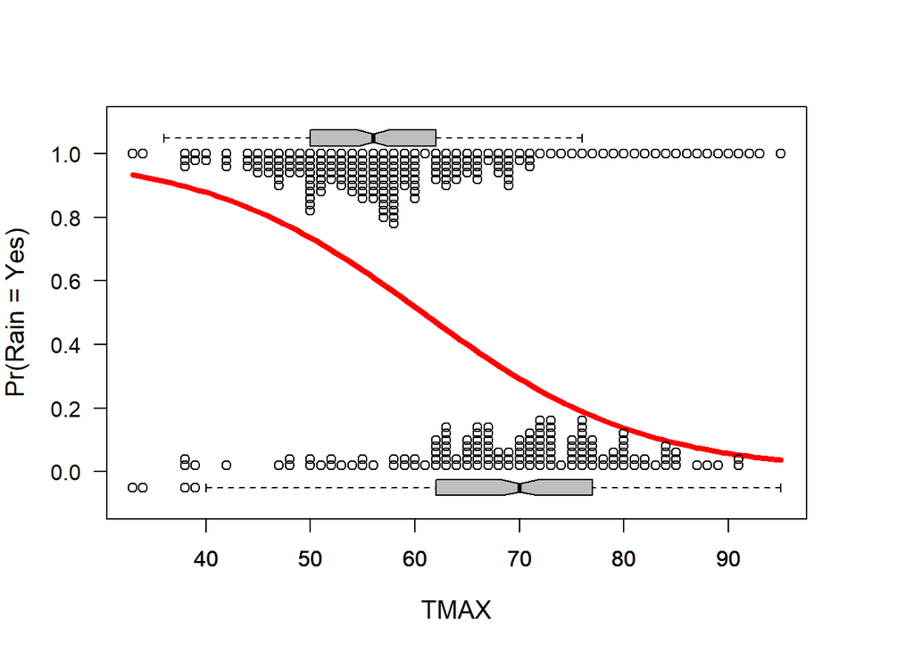

```r
library(popbio)
logi.hist.plot(rain_df$TMAX, rain_df$Rain, logi.mod = 1, boxp = TRUE, type = "dit", col = "gray", xlabel = "TMAX", ylabel = "Pr(Rain = Yes)")
```

# Exercise 15: Visualization

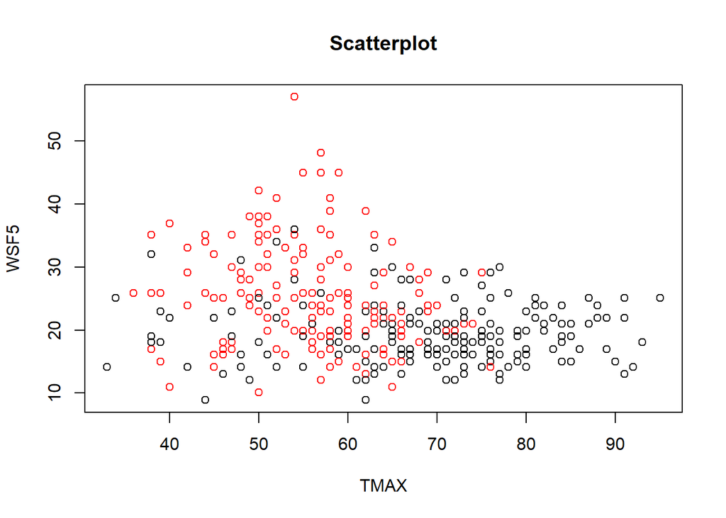

```r
# decisionplot function
# source: http://michael.hahsler.net/SMU/EMIS7332/R/viz_classifier.html

decisionplot <- function(model, data, class = NULL, predict_type = "class",
  resolution = 100, showgrid = TRUE, ...) {

  if(!is.null(class)) cl <- data[,class] else cl <- 1
  data <- data[,1:2]
  k <- length(unique(cl))

  plot(data, col = as.integer(cl)+1L, pch = as.integer(cl)+1L, ...)

  # make grid
  r <- sapply(data, range, na.rm = TRUE)
  xs <- seq(r[1,1], r[2,1], length.out = resolution)
  ys <- seq(r[1,2], r[2,2], length.out = resolution)
  g <- cbind(rep(xs, each=resolution), rep(ys, time = resolution))
  colnames(g) <- colnames(r)
  g <- as.data.frame(g)

  ### guess how to get class labels from predict
  ### (unfortunately not very consistent between models)
  p <- predict(model, g, type = predict_type)
  if(is.list(p)) p <- p$class
  p <- as.factor(p)

  if(showgrid) points(g, col = as.integer(p)+1L, pch = ".")

  z <- matrix(as.integer(p), nrow = resolution, byrow = TRUE)
  contour(xs, ys, z, add = TRUE, drawlabels = FALSE,
    lwd = 2, levels = (1:(k-1))+.5)

  invisible(z)
}




# Data Subset
rain_df.sub <- subset(rain_df, select=c(TMAX, WSF5, Rain))

# Plot XY
plot(rain_df.sub[, 1:2], col = rain_df.sub[, 3], main = "Scatterplot")
```

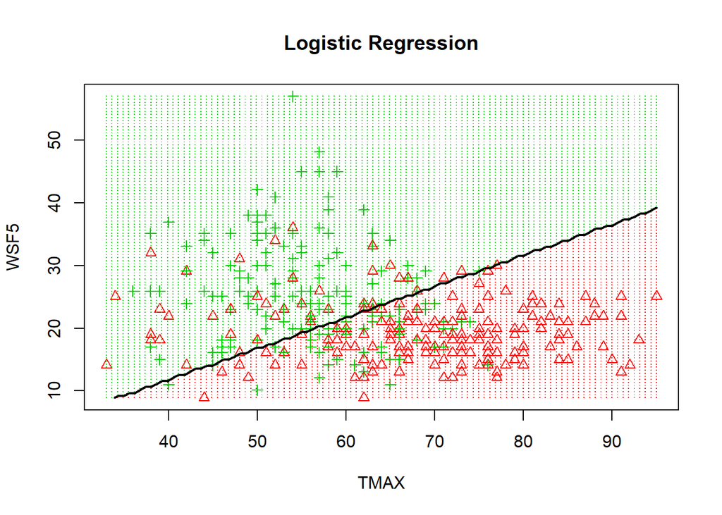

```r
# Plot Logistic Regression fit
model <- glm(Rain ~ TMAX+WSF5, data = train, family=binomial(link='logit'))
class(model) <- c("lr", class(model))
predict.lr <- function(object, newdata, ...)
  predict.glm(object, newdata, type = "response") > .5

decisionplot(model, rain_df.sub, class = "Rain", main = "Logistic Regression")
```

# Exercise 15 (Bonus): Logistic Regression with k-fold Cross Validation using **caret**

```
                            **ModernSchool Logistic Regression**
```

Using ML algorithms for Supervised prediction: LOGISTIC REGRESSION with Caret package.

```r
start.time <- Sys.time()

# Change the name of Classes
rain_df$Rain <- ifelse(rain_df$Rain == 1, "Yes", "No")
rain_df$Rain <- factor(rain_df$Rain)

inTrain <- createDataPartition(y = rain_df$Rain, p = 0.7, list = FALSE)
training <- rain_df[inTrain,]; testing <- rain_df[-inTrain,]
dim(training); dim(testing)
```

```
## [1] 257  11
```

```
## [1] 109  11
```

```r
table(training$Rain); table(testing$Rain)
```

```
##
##  No Yes
## 136 121
```

```
##
##  No Yes
##  58  51
```

```r
fitControl <- trainControl(# 10-fold CV
                           method = "repeatedcv",
                           number = 10,           # number of folds
                           repeats = 5,           # number of complete sets of folds to compute
                           classProbs = TRUE,     # Evaluate performance using the following function
                           summaryFunction = twoClassSummary,
                           returnResamp = "final",
                           savePredictions = T,   # for ROC
                           allowParallel = TRUE   # Parallel processing
                           )

# Logistic Regression
caret.logreg.fit <- train(Rain ~ Season+TMAX+TMIN+WSF5,
                data = training,
                preProc = c("center", "scale"),
                method = "glm",
                metric = "ROC",                    # Specify which metric to optimize
                tuneLength = 10,
                family = binomial(link = "logit"),
                trControl = fitControl
                )

# Print model results
print(caret.logreg.fit, digits = 3)
```

```
## Generalized Linear Model
##
## 257 samples
##   4 predictor
##   2 classes: 'No', 'Yes'
##
## Pre-processing: centered (6), scaled (6)
## Resampling: Cross-Validated (10 fold, repeated 5 times)
## Summary of sample sizes: 232, 232, 230, 231, 231, 231, ...
## Resampling results:
##
##   ROC    Sens   Spec
##   0.864  0.793  0.764
```

```r
print(caret.logreg.fit$finalModel, digits=3)
```

```
##
## Call:  NULL
##
## Coefficients:
##  (Intercept)  SeasonSpring  SeasonSummer  SeasonWinter          TMAX
##       -0.235        -0.281        -0.508         0.282        -3.054
##         TMIN          WSF5
##        2.599         0.712
##
## Degrees of Freedom: 256 Total (i.e. Null);  250 Residual
## Null Deviance:       355
## Residual Deviance: 222   AIC: 236
```

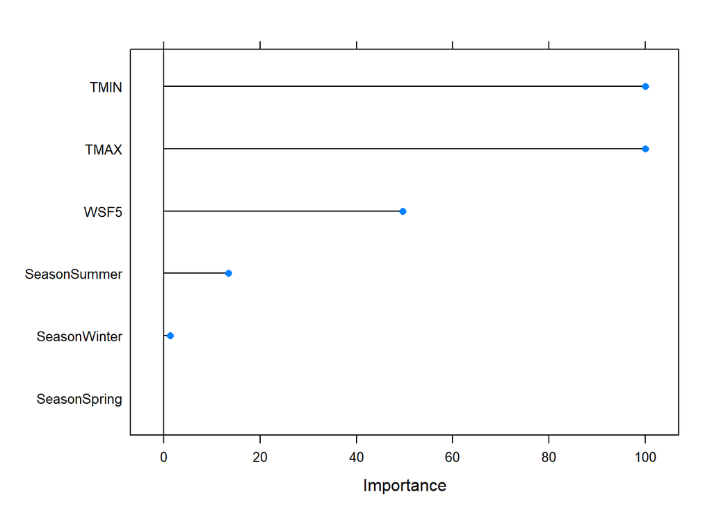

```r
# VImportance of Variable
plot(varImp(caret.logreg.fit, scale = TRUE))
```

```r
# Model Performance: Making Test Set Predictions
pred <- predict(caret.logreg.fit, newdata = testing)
confusionMatrix(pred, testing$Rain, positive = "Yes")
```

```
## Confusion Matrix and Statistics
##
##           Reference
## Prediction No Yes
##        No  45   6
##        Yes 13  45
##
##                Accuracy : 0.8257
##                  95% CI : (0.7413, 0.8917)
##     No Information Rate : 0.5321
##     P-Value [Acc > NIR] : 1.232e-10
##
##                   Kappa : 0.6528
##  Mcnemar's Test P-Value : 0.1687
##
##             Sensitivity : 0.8824
##             Specificity : 0.7759
##          Pos Pred Value : 0.7759
##          Neg Pred Value : 0.8824
##              Prevalence : 0.4679
##          Detection Rate : 0.4128
##    Detection Prevalence : 0.5321
##       Balanced Accuracy : 0.8291
##
##        'Positive' Class : Yes
##
```

La matriz de confusión muestra que el modelo está haciendo un buen trabajo de clasificación. La precisión general es del 83%, mientras que la sensibilidad es del 88% y la especificidad es del 78%.

```r
end.time <- Sys.time()
time.taken <- end.time - start.time
time.taken
```

```
## Time difference of 3.343306 secs
```

# ===================================

# HELP:

https://rpubs.com/Joaquin_AR/229736